# Notebook

### Step 0: Necessary imports and paths

First we import all of the modules we'll need for the analysis, and hardcode in some database information as well as pointers to the data and scripts.

```python
# Modules used in the analysis:
import collections
import IPython.display
import lupe.clustering.run
import lupe.statemachines.compute
import lupe.statemachines.paths
import lupe.transformations.barchart
import numpy
import subprocess
import matplotlib.pyplot as plt
import queryutils.databases
import queryutils.files
import queryutils.parse
import queryutils.versions
%matplotlib inline

# Hardcoded information:
USER = DATABASE = PASSWORD = "lupe_example" # Database parameters.
SPLUNK_QUERIES_DIR = "data" # Pointer to the example query data.
INIT_SCRIPT = "init_database.sh" # Script to set up the database.
```

### Step 1: Initialize the database

Next we set up the database to store the query data. The following lines first call a script to initialize a database with the hardcoded database parameters above, then creates a database object that we'll use to interact with the database, and then initializes the tables we'll store the data in.

```python
# Create the Postgres user and database.
subprocess.call([INIT_SCRIPT, USER, DATABASE, PASSWORD])
```

```
0
```

```python
# Grab a pointer to the database.
db = queryutils.databases.PostgresDB(USER, DATABASE, PASSWORD)
```

```
DEBUG:queryutils:Initialized data source.
```

```python
# Initialize the tables to store the queries.
db.initialize_tables()
```

[output not shown]

[output cut: 18 more lines]

[output not shown]

### Step 2: Populate the database.

The next two lines load the query data from the .csv files in the `data/` directory into the database. The first line adds data to the users and queries tables. The next line parses as many queries as it can and adds the parsed queries to the parsetrees table. We do this to speed access to the data, as reading from files and parsing the queries are slow. Not all queries will successfull parse. You can ignore these errors.

```python
# Load the example data set.
db.load_users_and_queries_from_source(queryutils.files.CSVFiles, SPLUNK_QUERIES_DIR, queryutils.versions.Version.FORMAT_2014)
```

[output not shown]

[output cut: 740 more lines]

[output not shown]

```python
# Load the parsed queries (because parsing is somewhat slow).
db.load_parsed() # Expect some parsing errors.
```

[output not shown]

[output cut: 1229 more lines]

[output not shown]

### Step 3: Getting an overview

We are finally ready to start analyzing the data. For this we will use a combination of methods from the `lupe` and `queryutils` modules. Below we illustrate some of the basic properties of the data. Feel free to play around and examine other basic properties. Can you output the number of users, for example?

```python
queries = [q for q in db.get_queries()]
print "Number of queries: %d" % len(queries)
```

```
Number of queries: 262
```

```python
nstages = [len(queryutils.parse.split_query_into_stages(q)) for q in queries]
print "Min, median, and max query length: %d, %d, %d" % (min(nstages), numpy.median(nstages), max(nstages))
```

```
Min, median, and max query length: 1, 4, 22
```

```python
# How many queries were successfully parsed?
parsetrees = [p for p in db.get_parsetrees()]
print "Number of queries parsed: %d" % len(parsetrees)
```

```
Number of queries parsed: 189
```

```python
command_counts = collections.defaultdict(int)
for query in queries:
    tokens = queryutils.parse.tokenize_query(query)
    command_tokens = filter(lambda x: x.type not in ["ARGS", "PIPE", "LBRACKET", "RBRACKET"], tokens)
    commands = [t.value.lower() for t in command_tokens]
    for command in commands:
        if command == 'index="os"':
            print query
        command_counts[command] += 1
command_counts_sorted = sorted(command_counts.items(), key=lambda x: x[1], reverse=True)
print "command, count"
for command, count in command_counts_sorted:
    print "%s, %d" % (command, count)
```

```
command, count
eval, 426
search, 329
stats, 163
timechart, 76
fields, 65
lookup, 61
rename, 59
multikv, 48
addinfo, 46
top, 34
fillnull, 26
sitop, 21
join, 18
sort, 14
dedup, 13
appendcols, 13
chart, 13
append, 11
transaction, 11
makemv, 7
mvexpand, 6
where, 6
streamstats, 6
delete, 6
strcat, 5
fieldformat, 4
bucket, 4
bin, 3
rex, 3
convert, 3
metadata, 2
head, 2
outputlookup, 2
typer, 2
inputlookup, 2
sistats, 1
```

### Step 4: Imposing high-level categorization to understand tasks

After getting a basic overview, we'll next look at how many different types of *transformations* are represented by the queries. A tranformation is a category of operation performed by Splunk commands -- each Splunk command corresponds to one transformation. This part of the analysis corresponds to Section 5 of the LISA paper, and step 4 in the wiki page of the lupe repository.

```
ERROR:queryutils:Unknown command type: typer
ERROR:queryutils:Unknown command type: typer
```

```
Augment, 33.1, 51.9
Filter, 23.2, 100.0
Aggregate, 19.7, 75.2
Transform, 6.2, 29.0
Join, 5.2, 25.6
Project, 4.3, 13.4
Rename, 3.9, 12.2
Cache, 1.5, 8.4
Reorder, 0.9, 5.3
Set, 0.7, 3.4
Window, 0.4, 2.3
Meta, 0.4, 2.3
Input, 0.3, 1.5
Output, 0.1, 0.8
```

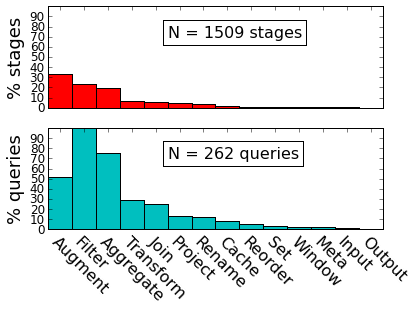

```python
stage_pcts, nstages, query_pcts, nqueries = lupe.transformations.barchart.tally(db, "scheduled", False)
lupe.transformations.barchart.plot_barchart(stage_pcts, nstages, query_pcts, nqueries, False, "figs/example-transformation-barchart.png")
```

These two subplots show the proportion of transformations in the data. The top graph shows, for all stages, what percent correspond to each transformation type. The bottom graph shows, for each query, what percent contains at least one of each transformation type. The most common type of transformations in this data set are **Augment**, **Filter**, and **Aggregate**. We will look into these categories in more detail in Step 6.

### Step 5: Understanding workflows via Markov diagrams and common subsequences

Next we'll look at the distribution of sequences of transformations in the query data. We will do this by tallying how many times stages corresponding to one transformation type are followed by stages corresponding to another transformation type. We use these *transition frequencies* to create a Markov diagram that summarizes the types of analysis pipelines represented by the query data.

```python
lupe.statemachines.compute.markov_diagram(db, "figs/example-fsm.png", "scheduled")
```

```
ERROR:queryutils:Unknown command type: typer
ERROR:queryutils:Unknown command type: typer
```

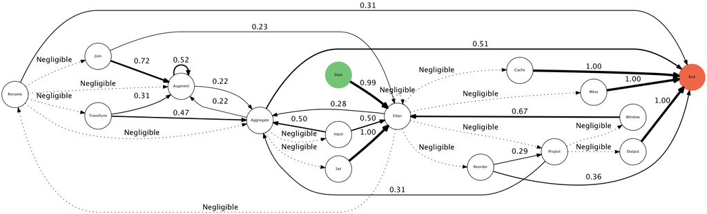

```python
IPython.display.Image("figs/example-fsm.png")
```

We can look at not only this diagram, but compute some of paths through this diagram and rank them by how often they would be traced through the graph were we to travel paths through the graph based on transition frequencies.

```python
lupe.statemachines.paths.compute_top_paths(db, "scheduled")
```

```
ERROR:queryutils:Unknown command type: typer
ERROR:queryutils:Unknown command type: typer
```

[output not shown]

[output cut: 21 more lines]

```
Start Input Filter Meta End  6.54307524537e-05
Start Filter Filter Project End  5.83268421873e-05
Start Filter Augment Window End  5.67066521265e-05
Start Input Filter Rename End  5.32317986064e-05
Start Input Aggregate Rename End  4.31276146116e-05
Start Input Aggregate Aggregate End  3.89429026949e-05
Start Filter Project Filter End  3.78875214208e-05
Start Input Aggregate Reorder End  3.21278947233e-05
Start Input Filter Reorder End  2.72628135224e-05
Start Input Filter Transform End  2.22742987076e-05
Start Filter Reorder Augment End  1.98473282443e-05
Start Input Aggregate Project End  1.77939109237e-05
Start Input Filter Filter End  1.53918055772e-05
Start Input Aggregate Output End  1.28511578893e-05
Start Input Aggregate Augment End  1.15146374688e-05
```

### Step 6: Creating second-level categorization via clustering to understand sub-tasks

Lastly, we'll look at the differences between different types of **Filter**, **Augment**, and **Aggregate** transformations, by featurizing stages of each of these types and performing cluster analysis of them.

The clustering code in this part outputs not only static graphs, but also data that you can explore using an interactive JavaScript-based visualization tool included in the [lupe repo](https://github.com/salspaugh/lupe).

[output not shown]

```
Writing data.dat
Dimension of projection : 2
Perplexity : 50
Landmarks(ratio) : 1.000000
Platform detected : darwin
Calling executable "tSNE_maci"
Reading result.dat
Clearing data.dat and result.dat
Reordering results
```

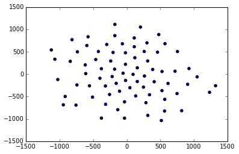

```python
# Cluster augment stages.
lupe.clustering.run.run(db, 9, None, "augments01", "augments", None,
                        "figs/example-augments-clusters", "figs/example-augments-features", "figs/example-augments-mouseovers",
                        None, None, 129, True)
```

Unfortunately, with this data, we don't get very nicely separated **Augment** clusters. You can experiment with different parameter settings to see if you get better clusters. You can also output the stages corresponding to the feature vectors being plotted above, as shown in the commented-out code below. Currently these lines are commented out because they outputs a lot of text.

```python
# Print unique Augment stages.
#for stage in db.get_unique_augments():
#    stage.print_tree()
#    print
```

We do the same things for the **Filter** stages.

[output not shown]

```
Writing data.dat
Dimension of projection : 2
Perplexity : 50
Landmarks(ratio) : 1.000000
Platform detected : darwin
Calling executable "tSNE_maci"
Reading result.dat
Clearing data.dat and result.dat
Reordering results
```

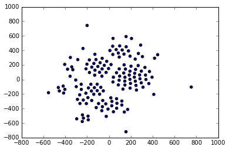

```python
# Cluster filter stages.
lupe.clustering.run.run(db, 9, None, "filters01", "filters", None,
                        "figs/example-filters-clusters", "figs/example-filters-features", "figs/example-filters-mouseovers",
                        None, None, 28, True)
```

Here we get much nicer clusters that we can explore and label using the interactive cluster labeling tool in the [lupe repo](https://github.com/salspaugh/lupe).

```python
# Print unique Filter stages.
#for stage in db.get_unique_filters():
#    stage.print_tree()
#    print
```

Lastly we try this on the **Aggregate** stages. Here too we get nicer clusters.

[output not shown]

```
Writing data.dat
Dimension of projection : 2
Perplexity : 50
Landmarks(ratio) : 1.000000
Platform detected : darwin
Calling executable "tSNE_maci"
Reading result.dat
Clearing data.dat and result.dat
Reordering results
```

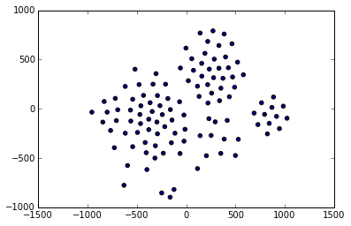

```python
lupe.clustering.run.run(db, 9, None, "aggregates01", "aggregates", None,
                        "figs/example-aggregates-clusters", "figs/example-aggregates-features", "figs/example-aggregates-mouseovers",
                        None, None, 40, True)
```

```python
# Print unique Aggregate stages.
#for stage in db.get_unique_aggregates():
#    stage.print_tree()
#   print
```